# Pessoas com deficiência - Novo CAGED

Nabil Murtadha e Laura Gontijo - Instituto Ensino e Pesquisa APAE Brasil

# 1 Série Histórica do Novo CAGED

A seguir, analisamos alguns dados do Novo Caged com relação ao saldo de empregos formais no país a partir do ano de 2020.

O **Novo Caged**, instituído pela **Lei nº 4.923/65**, é uma fonte de informações de âmbito nacional e periodicidade mensal, criado como instrumento de acompanhamento e fiscalização do processo de admissão e dispensa de trabalhadores regidos pela CLT. Esse instrumento permite avaliar a rotatividade e flutuação da mão de obra. É possível verificar o impacto de crises econômicas e outras flutuações da economia sobre o mercado de trabalho. Segundo pesquisadores, a pandemia da Covid-19 lançou a economia mundial na pior recessão desde a Segunda Guerra Mundial.

## 1.1 Saldo da série total

No que diz respeito ao mercado de trabalho brasileiro, conforme podemos observar, no mês de **abril de 2020**, o país registrou uma perda de **902.317** postos de trabalho. Em **maio**, a situação permanece ruim com um saldo negativo de **352.790** postos de trabalho. Em seguida, há uma pequena recuperação no nível de empregos com uma nova queda abrupta em dezembro de 2021.

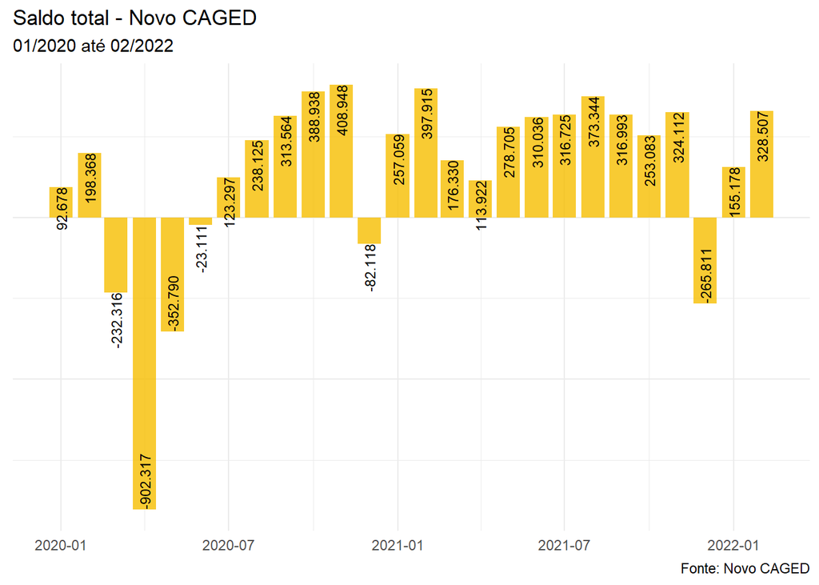

## 1.2 Saldo da série de pessoas com deficiência

Quando observamos a situação das pessoas com deficiência empregadas no emprego formal, ou seja, com vínculos celetistas ou estatutários, é possível concluir que no mês de **abril de 2020**, **8.669** pessoas com deficiência foram desligadas, em **maio** teve-se uma perda de **6.162** postos de trabalho ocupados por pessoas com deficiência e em seguida, em **junho**, uma perda de **2.999** empregos.

A situação não melhorou muito para as pessoas com deficiência nos meses seguintes, é possível observar que, enquanto nos meses de dezembro/2020 a abril/2021, quando o estoque de empregos em geral ficou relativamente positivo, o estoque de empregos que eram ocupados por pessoas com deficiência continuou em queda.

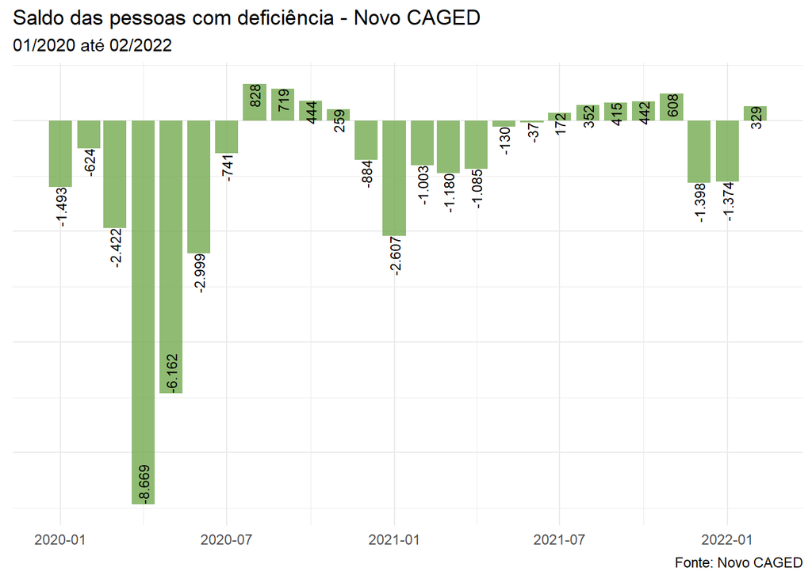

## 1.3 Saldos padronizados

É possível perceber a partir desses dados que se os trabalhadores brasileiros de um modo geral sofreram muito com os impactos da pandemia da Covid-19 sobre os postos de trabalho, as pessoas com deficiência sofreram ainda mais esses impactos.

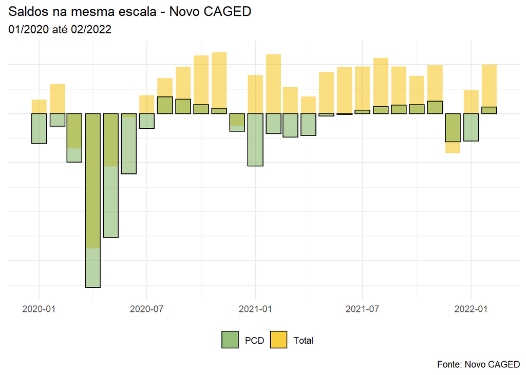